# Green Regional Path paper: First results

# 3 Patent application development

- In the following, a brief descriptive analysis of the development of green and non-green patent application in the Nordics
- In addition, a breackdown of green patents by top green patenting regions

```r
# Dataframe with regions and technology fields
tech_dev <- region_RTA %>%
  select(country, period, nuts, nuts_period, isic4_l3, Y_tag, n_tech_region, rta, rta_bin) %>%
  arrange(country, nuts, isic4_l3, Y_tag, period) %>%
  group_by(country, nuts, isic4_l3, Y_tag) %>%
  mutate(n_tech_region_lag = lag(n_tech_region, 1),
         n_tech_region_delta = n_tech_region - n_tech_region_lag,
         pct_tech_region_delta = (n_tech_region - n_tech_region_lag) / ( n_tech_region_lag + 1),
         rta_lag = lag(rta, 1),
         rta_delta = rta - rta_lag,
         rta_bin_lag = lag(rta_bin, 1),
         rta_bin_delta = rta_bin - rta_bin_lag) %>%
  ungroup() %>%
  arrange(country, nuts, isic4_l3, Y_tag, period)
```

!! TODO ADJUST FOR COUNRTY!

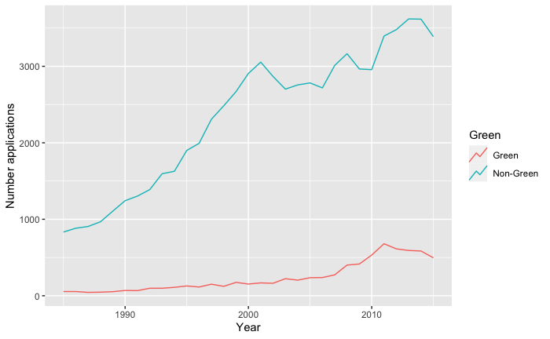

```r
data_appln %>%
  semi_join(appln_invt_nordic, by = 'appln_id') %>%
  mutate(Y_tag = ifelse(Y_tag == TRUE, 'Green', 'Non-Green')) %>%
  filter(appln_filing_year <= 2015, appln_filing_year >= 1985) %>%
  count(appln_filing_year, Y_tag) %>%
  ggplot(aes(x = appln_filing_year, y = n, col = Y_tag)) +
  geom_line(key_glyph = "timeseries") +
  labs(#title = 'Patent applications: Development',
       #subtitle = 'All Nordic contries, by Y tag',
       x = 'Year',
       y = 'Number applications',
       col = 'Green')
```

```r
data_pers_appln %<>%
  inner_join(data_appln %>% select(appln_id, appln_filing_year), by = 'appln_id')
```

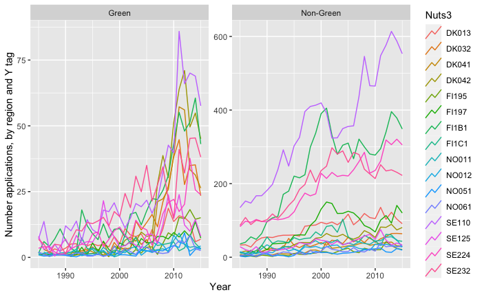

```r
data_pers_appln %>%
  filter(nuts %in% select_region) %>%
  mutate(Y_tag = ifelse(Y_tag == TRUE, 'Green', 'Non-Green')) %>%
  filter(appln_filing_year <= 2015, appln_filing_year >= 1985) %>%
  count(appln_filing_year, nuts, Y_tag, wt = pers_frac) %>%
  ggplot(aes(x = appln_filing_year, y = n, col = nuts)) +
  geom_line(key_glyph = "timeseries") +
  facet_wrap(vars(Y_tag), scales = 'free') +
  labs(#title = 'Patent applications: Development',
       #subtitle = 'All Nordic countries',
       x = 'Year',
       y = 'Number applications, by region and Y tag',
       col = 'Nuts3')
```

# 4 Applicants

- Applicants of patents filed by inventors in the Nordics
- That can be domestic or foreign applicants

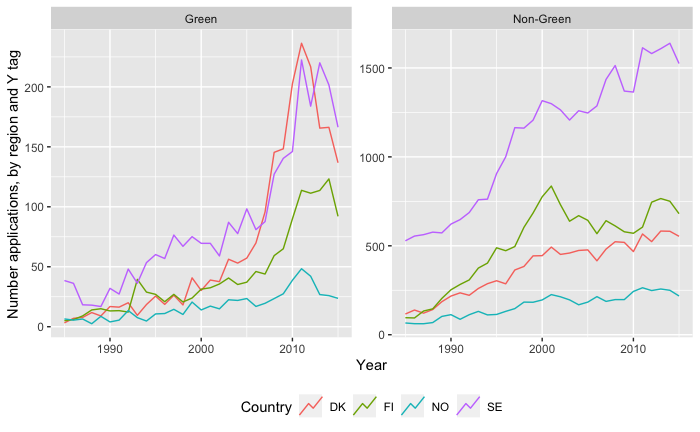

```r
data_pers_appln %>%
  filter(person_ctry_code %in% select_country) %>%
  mutate(Y_tag = ifelse(Y_tag == TRUE, 'Green', 'Non-Green')) %>%
  filter(appln_filing_year <= 2015, appln_filing_year >= 1985) %>%
  count(appln_filing_year, person_ctry_code, Y_tag, wt = pers_frac) %>%
  ggplot(aes(x = appln_filing_year, y = n, col = person_ctry_code)) +
  geom_line(key_glyph = "timeseries") +
  facet_wrap(vars(Y_tag), scales = 'free') +
    theme(legend.position = 'bottom') +
  labs(#title = 'Patent applications: Development by country',
       #subtitle = 'All Nordic contries',
       x = 'Year',
       y = 'Number applications, by region and Y tag',
       col = 'Country')
```

```r
#ggsave("../output/paper_figs/fig_3.jpeg", dpi = 300)
#ggsave("../output/paper_figs/fig_3.eps")
```

```r
region_applt_appln %<>%
  left_join(region_applt %>% select(person_id, han_id, han_name, person_ctry_code, nuts), by = 'person_id') %>%
  left_join(data_appln %>% select(appln_id, docdb_family_id, appln_filing_year, period), by = 'appln_id') %>%
  left_join(data_appln_isic %>% select(docdb_family_id, isic4_l3, isic_frac) %>% nest(isic = c(isic4_l3, isic_frac)), by = 'docdb_family_id') %>%
  drop_na()
```

```r
# List main applicants
applt_stats <- region_applt_appln %>%
  filter(person_ctry_code %in% select_country) %>%
  group_by(han_id, han_name) %>%
  summarise(
    n_pat = sum(applt_frac),
    n_Y = sum(applt_frac * Y_tag),
    first_pat = min(appln_filing_year)
    ) %>%
  mutate(share_Y = n_Y / n_pat,
         age = 2016 - first_pat,
         incumbant = age >= 10 & n_pat >= 10) %>%
  ungroup() %>%
  arrange(desc(n_pat))
```

```r
applt_stats %>% head(200)
```

| han_id | han_name | n_pat | n_Y | first_pat | share_Y | age | incumbant |
| --- | --- | --- | --- | --- | --- | --- | --- |
| 13378 | TELEFON AB LM ERICSSON PUBL | 9468.00 | 477.500 | 1985 | 0.050433 | 31 | TRUE |
| 2125445 | NOKIA CORP | 4203.15 | 156.000 | 1988 | 0.037115 | 28 | TRUE |
| 2562294 | NOKIA TECH LTD | 1639.62 | 130.000 | 1996 | 0.079287 | 20 | TRUE |
| 172077 | ASTRAZENECA AB | 840.50 | 17.000 | 1990 | 0.020226 | 26 | TRUE |
| 2136895 | NOVO NORDISK AS | 833.83 | 4.000 | 1985 | 0.004797 | 31 | TRUE |
| 16989 | AB SKF | 792.50 | 56.500 | 1985 | 0.071293 | 31 | TRUE |
| 1492908 | NOVOZYMES AS | 662.50 | 93.000 | 1987 | 0.140377 | 29 | TRUE |
| 3158192 | VESTAS WIND SYSTEMS AS | 645.00 | 597.000 | 1999 | 0.925581 | 17 | TRUE |
| 2538622 | SANDVIK INTELLECTUAL PROPERTY AB | 637.00 | 13.000 | 1993 | 0.020408 | 23 | TRUE |
| 1688551 | KONE CORP | 629.50 | 19.000 | 1992 | 0.030183 | 24 | TRUE |

[output cut: 190 more lines]

```r
applt_stats %>% arrange(desc(n_Y)) %>% head(100)
```

| han_id | han_name | n_pat | n_Y | first_pat | share_Y | age | incumbant |
| --- | --- | --- | --- | --- | --- | --- | --- |
| 3158192 | VESTAS WIND SYSTEMS AS | 645.00 | 597.00 | 1999 | 0.92558 | 17 | TRUE |
| 13378 | TELEFON AB LM ERICSSON PUBL | 9468.00 | 477.50 | 1985 | 0.05043 | 31 | TRUE |
| 2652263 | SCANIA CV AB | 529.00 | 159.00 | 1990 | 0.30057 | 26 | TRUE |
| 2125445 | NOKIA CORP | 4203.15 | 156.00 | 1988 | 0.03712 | 28 | TRUE |
| 3204434 | WARTSILA FINLAND LTD | 341.00 | 144.00 | 1996 | 0.42229 | 20 | TRUE |
| 2562294 | NOKIA TECH LTD | 1639.62 | 130.00 | 1996 | 0.07929 | 20 | TRUE |
| 3245288 | VOLVO LASTVAGNAR AB | 529.50 | 113.50 | 1994 | 0.21435 | 22 | TRUE |
| 4326419 | SIEMENS GAMESA RENEWABLE ENERGY AS | 104.00 | 95.00 | 2006 | 0.91346 | 10 | TRUE |
| 1492908 | NOVOZYMES AS | 662.50 | 93.00 | 1987 | 0.14038 | 29 | TRUE |
| 3188958 | VOLVO TRUCK CORP | 188.00 | 78.00 | 1997 | 0.41489 | 19 | TRUE |

[output cut: 90 more lines]

# 5 Y TAgs

```r
# Share of incumbants by technology
region_techn_incumb <- region_applt_appln %>%
  filter(person_ctry_code %in% select_country) %>%
  left_join(applt_stats %>% select(han_id, incumbant), by = 'han_id') %>%
  unnest(isic) %>%
  mutate(n_weight = isic_frac * applt_frac) %>%
  group_by(nuts, isic4_l3, period, Y_tag) %>%
  summarise(n = sum(n_weight),
            n_inc = sum(n_weight * incumbant)) %>%
  ungroup() %>%
  mutate(share_inc = n_inc / n)
```

# 6 Technology space general

- We calculate the relatedness of industries by co-occurence pattern following Hidalgo & Hausmann (2007)
- Revealed technological advantage (RTA) Is sepperatedly calculated for Y-tag and non-Y-tag patents.

```r
data_docdb_fam_cpc %>%
  semi_join(appln_invt_nordic, by = 'docdb_family_id') %>%
  filter(Y_tag == TRUE) %>%
  mutate(cpc_class_symbol = cpc_class_symbol %>% str_sub(1,4)) %>%
  count(cpc_class_symbol, sort = TRUE)
```

| cpc_class_symbol | n |
| --- | --- |
| Y02E | 3921 |
| Y02T | 1937 |
| Y02P | 1742 |
| Y02A | 808 |
| Y02D | 784 |
| Y02B | 705 |
| Y02W | 474 |
| Y04S | 214 |
| Y02C | 107 |

```r
set.seed(1337)
coords_tech <- g_tech %>% igraph::layout.fruchterman.reingold() %>% as_tibble()
colnames(coords_tech) <- c("x", "y")
```

# 7 Regional specialization (RTA) development

- Comparison of specialization provides in period 1 and 2

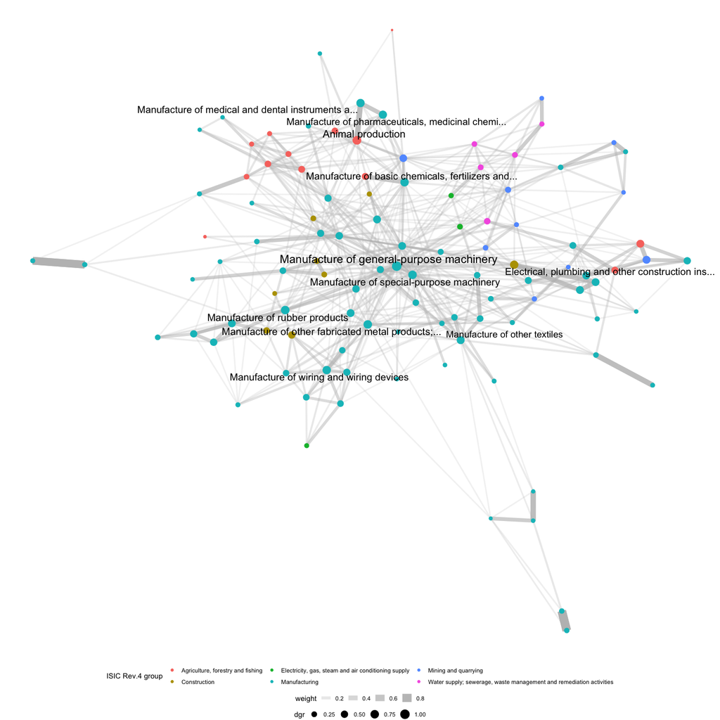

```r
g_tech %N>%
  mutate(isic4_l3_name = isic4_l3_name %>% str_trunc(50, side = 'right')) %>%
  ggraph(layout =  coords_tech) +
  geom_edge_link(aes(width = weight, alpha = weight), colour = "grey") +
  geom_node_point(aes(colour = isic4_l1_name, size = dgr)) +
  geom_node_text(aes(label = isic4_l3_name, size = dgr, filter = percent_rank(dgr) >= 0.90 ), repel = TRUE) +
  theme_void() +
  theme(legend.position = 'bottom',
        legend.box = "vertical") +
  labs(col = 'ISIC Rev.4 group'
         #title = 'Industry Space (all Nordics)',
       #subtitle = 'Nodes = NACE 2 Industries. Edges: Relatedness'
    )
```

```r
#ggsave("../output/paper_figs/fig_9.jpeg", dpi = 300)
#ggsave("../output/paper_figs/fig_9.eps")
```

```r
p1 <- region_RTA_agg  %>%
  filter(nuts %in% select_region) %>%
  pivot_wider(names_from = Y_tag, values_from = c(n_spec, n_spec_count, HHI), values_fill = 0, names_prefix = 'Y_tag_')

p2 <- p1 %>%
  select(period, nuts, n_spec_Y_tag_FALSE, n_spec_Y_tag_TRUE) %>%
  pivot_wider(names_from = period, values_from = c(n_spec_Y_tag_FALSE, n_spec_Y_tag_TRUE))
```

# 8 Analysis for existing green paths:

NOTE: new patents in specializations?

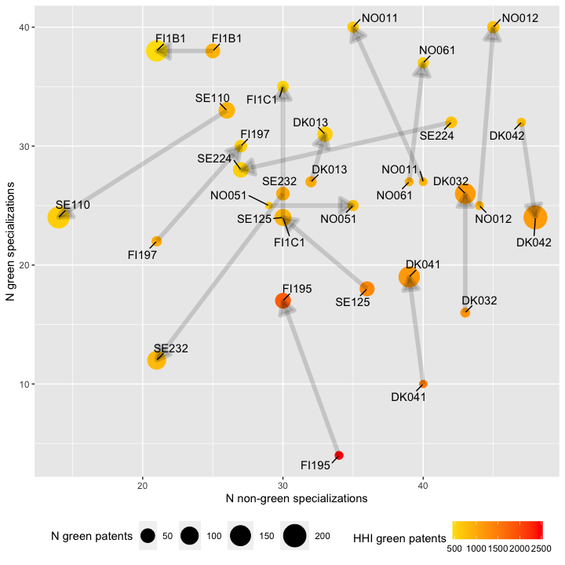

```r
p1 %>%
  ggplot(aes(x = n_spec_Y_tag_FALSE, y = n_spec_Y_tag_TRUE)) +
  geom_point(aes(size = n_spec_count_Y_tag_TRUE, col = HHI_Y_tag_TRUE)) +
  geom_segment(data = p2,
               aes(x = n_spec_Y_tag_FALSE_1,
                   y = n_spec_Y_tag_TRUE_1,
                   xend = n_spec_Y_tag_FALSE_2,
                   yend = n_spec_Y_tag_TRUE_2,
                   size = 0.75),
               alpha = 0.15,
               arrow = arrow(length = unit(0.5, "cm"), type = "closed"),
               show.legend = FALSE) +
  geom_text_repel(aes(label = nuts), box.padding = 0.5, max.overlaps = Inf) +
  scale_color_gradient2(low = "skyblue", mid = 'yellow', high = "red", midpoint = 1) +
  scale_size(range = c(2, 10)) +
  theme(legend.position = 'bottom') +
  labs(#title = 'Development of new regional specializations',
       #subtitle = 'By number of green and non green specializations in period 1 and 2',
       x = 'N non-green specializations',
       y = 'N green specializations',
       size = 'N green patents',
       col = 'HHI green patents')
```

```r
# ggsave("../output/paper_figs/fig_4.jpeg", dpi = 300)
#ggsave("../output/paper_figs/fig_4.eps")

rm(p1, p2)
```

```r
tech_rel_dev <- tech_rel %>%
  select(from, to, weight) %>%
  inner_join(tech_dev %>% distinct(isic4_l3, nuts), by = c('from' = 'isic4_l3')) %>%
  # filter for rta in period 1
  inner_join(tech_dev %>% filter(period == '1', rta_bin == 1) %>% distinct(isic4_l3, nuts, Y_tag), by = c('to' = 'isic4_l3', 'nuts')) %>%
  # filter for new green specialization in period 2
  semi_join(tech_dev %>% filter(period == '2', rta_bin == 1, rta_bin_delta == 1, Y_tag == TRUE), by = c('from' = 'isic4_l3', 'nuts')) %>%
  rename(isic4_l3= from, related_techn = to)
```

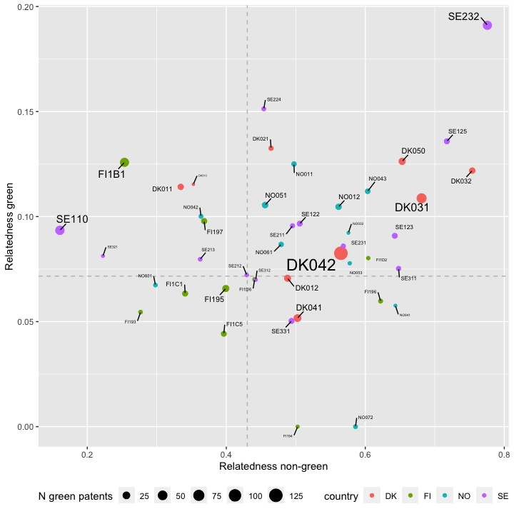

```r
p1 <- tech_rel_dev %>%
  group_by(nuts, isic4_l3, Y_tag) %>%
  summarise(rel_max = weight %>% max(),
            rel_sum = weight %>% sum(),
            rel_mean = weight %>% mean()) %>%
  ungroup() %>%
  #
  group_by(nuts, Y_tag) %>%
  summarise(rel = rel_max %>% mean()) %>%
  ungroup() %>%
  #
  pivot_wider(names_from = Y_tag, values_from = rel, names_prefix = 'Y_', values_fill = 0) %>%
  left_join(tech_dev %>% filter(Y_tag == TRUE, period == '2', rta_bin_delta == 1) %>% select(nuts , n_tech_region) %>% count(nuts, wt = n_tech_region), by = c('nuts')) %>%
  mutate(country = nuts %>% str_sub(1,2))
x_mid <- mean(p1$Y_FALSE, na.rm = TRUE)
y_mid <- mean(p1$Y_TRUE, na.rm = TRUE)

p1 %>%
  filter(country %in% select_country,
         0.5 <= percent_rank(n)) %>%
  ggplot(aes(x = Y_FALSE, y = Y_TRUE, size = n)) +
  geom_vline(xintercept = x_mid, linetype = "dashed", color = 'grey') +
  geom_hline(yintercept = y_mid, linetype = "dashed", color = 'grey') +
  geom_point(aes(col = country)) +
  geom_text_repel(aes(label = nuts), box.padding = 0.5, max.overlaps = Inf) +
  theme(legend.position="bottom") +
    labs(#title = 'New green specialization period 2',
       #subtitle = 'By nuts regions',
       #note = 'Relatedness is the mean over all new green specializations, per green specialization largest relatedness to former specialization counted',
       x = 'Relatedness non-green',
       y = 'Relatedness green',
       size = 'N green patents')
```

```r
#ggsave("../output/paper_figs/fig_5.jpeg", dpi = 300)
#ggsave("../output/paper_figs/fig_5.eps")

rm(p1, x_mid, y_mid)
```

```r
library(regions)
data(nuts_changes)
list_nuts <- nuts_changes %>% select(code_2021, geo_name_2021)
colnames(list_nuts) <- c('nuts', 'nuts_name')

list_nuts_add <- tibble(
  nuts = c('NO011', 'NO012', 'NO021', 'NO022', 'NO031', 'NO032', 'NO033', 'NO034', 'NO041', 'NO042', 'NO043', 'NO051', 'NO052', 'NO053', 'NO061', 'NO062', 'NO071', 'NO072', 'NO073'),
  nuts_name = c('Oslo', 'Akershus', 'Hedmark', 'Oppland', 'Østfold', 'Buskerud', 'Vestfold', 'Telemark', 'Aust-Agder', 'Vest-Agder', 'Rogaland', 'Hordaland', 'Sogn og Fjordane', 'Møre og Romsdal', 'Sør-Trøndelag', 'Nord-Trøndelag', 'Nordland', 'Troms', 'Finnmark')
)

list_nuts %<>% bind_rows(list_nuts_add)
```

```r
list_isic %>%
  filter(level ==3) %>%
    select(isic4_l1, isic4_l3, isic4_l4_name, isic4_l1_name)
```

| isic4_l1 | isic4_l3 | isic4_l4_name | isic4_l1_name |
| --- | --- | --- | --- |
| A | 011 | Growing of non-perennial crops | Agriculture, forestry and fishing |
| A | 012 | Growing of perennial crops | Agriculture, forestry and fishing |
| A | 013 | Plant propagation | Agriculture, forestry and fishing |
| A | 014 | Animal production | Agriculture, forestry and fishing |
| A | 015 | Mixed farming | Agriculture, forestry and fishing |
| A | 016 | Support activities to agriculture and post-harvest crop activities | Agriculture, forestry and fishing |
| A | 017 | Hunting, trapping and related service activities | Agriculture, forestry and fishing |
| A | 021 | Silviculture and other forestry activities | Agriculture, forestry and fishing |
| A | 022 | Logging | Agriculture, forestry and fishing |
| A | 023 | Gathering of non-wood forest products | Agriculture, forestry and fishing |

[output cut: 228 more lines]

!!! Make additio nal ploty including old green specializations